# Assignment 6 - Reproducability

Daniel Wilson

31/Oct/2025

Vargas Soto J. S., Beirne C., Whitworth A., Cruz Diaz J. C., Flatt E., Pillco-Huarcaya R., Olson E. R., Azofeifa A., Saborío-R G., Salom-Pérez R., Espinoza-Muñoz D., Hay L., Whittaker L., Roldán C., Bedoya-Arrieta R., Broadbent E. N., & Molnár P. K. (2021). Human disturbance and shifts in vertebrate community composition in a biodiversity hotspot. *Conservation Biology. 36*(2), e13813. https://doi.org/10.1111/cobi.13813  
**Introduction**  
This paper by Vergas Soto et al. (2021) examines how land use and human activities affect terrestrial vertebrates on the Osa-Golfito region of Costa Rica. This area, specifically the Osa Peninsula, houses many species that are of concern from a conservation standpoint including the jaguar and Baird’s tapir. The paper aimed to observe the distribution and co-occurrence of mammals and ground-birds in relation to human land management practices like land protection and development. The study also aimed to include a variety of species in their analyses to better represent the effects that land management has on the vertebrate ecosystem.  
**Methods**  
The Osa-Golfito region of Costa Rica served as the study area. This area of the country has a tropical climate and has experienced significant land use changes. The majority of original forests in the area have been replaced by pasture and plantations. However, conservation efforts have seen the creation of several protected areas in an attempt to preserve biodiversity. Because of these protected areas and a national ban on hunting, forests and animals have been able to recolonize much of the area. This led to around 70% of the land cover consisting of primary and secondary successional forests.  
Vergas Soto et al. (2021) conducted this study using a camera trap survey method. Baitless cameras were situated 30-50cm above the ground with preference for location along game trails. The researchers distributed 120 camera trap stations within the study area (Figure 1) across a variety of habitat types and land uses. The stations were separated by 1000m to ensure independence between them for species with large home ranges. The stations remained functional for an average of 117 days; well over the minimum necessary period to determine local diversity of 28 days. Vergas Soto et al. (2021) also enlisted the help of local communities in setting up and monitoring camera stations totaling 241 cameras. To ensure data collection followed a consistent set of methods, a detailed protocol was distributed to local volunteers with camera-trapping experience, and non-experienced participants were accompanied by a trained group.  
Using the photos collected by the camera stations, the authors identified all of the species captured and recorded the time, location, and date of the observation. With this data, the authors were able to make species richness comparison and joint species distribution model comparing species vs. species and species vs. land use category.  
Figure 1.

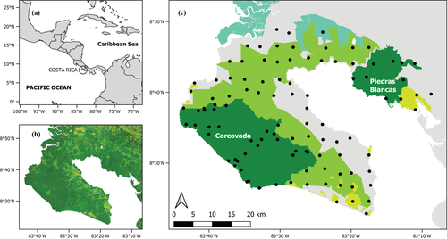

Figure 1. (top left) location of the Osa Peninsula in the context of Central America and Costa Rica. (bottom left) satellite imagery of the Osa Peninsula showing the high proportion of forested land in the region. (right) black dots representing the location of the camera trap stations and coloured based on the protection status. Dark green, national parks; light green, forest reserves; teal, protected wetlands; yellow, wildlife refuges; and grey, unprotected lands.  
**Results and Conclusions**  
The authors were able to accomplish the goals outlined in the introduction.  
The results of the study successfully analyzed the co-occurrence of medium to large mammals and ground birds in a joint species analysis. In total, the paper was able to gather enough data on 22 species and used joint species distribution modelling to analyze them in relation to each other. They found that several species’ distributions are related, both positively and negatively, depending on the species considered. The authors were also able to model how the different land management categories impacted each of these species. Large-bodied carnivores and herbivores, like tapir, pumas, and jaguar were seen to be extremely less common in human-disturbed sites whereas smaller species like opossums and armadillos were found in higher abundance in human-disturbed areas.  
Overall, higher species richness was found in protected areas. The two national parks differed in richness however, with the smaller park hosting more species richness than the larger. The authors hypothesize this is most likely due to a major river and roadway segmenting the larger park, leading to a lack of functional connectivity. Despite seeing higher rates of the smaller-bodied, generalist species, non-protected lands still saw lower species richness all together compared to the protected areas.